# IODS course project

##### black

- 1000(Bk - 0.63)^2 where Bk is the proportion of blacks by town
- left skewed distribution
- over 80 % of observations have value greater than 364
- black doesn’t have either high positive or high negative correlation with other variables

Note. Histogram is combined with density plot!

```r
summary(Boston$black)
```

```
##    Min. 1st Qu.  Median    Mean 3rd Qu.    Max.
##    0.32  375.38  391.44  356.67  396.23  396.90
```

```r
quantile(Boston$black, probs = seq(0, 1, 0.1))
```

```
##      0%     10%     20%     30%     40%     50%     60%     70%     80%
##   0.320 290.270 364.310 378.665 387.970 391.440 393.530 395.465 396.900
##     90%    100%
## 396.900 396.900
```

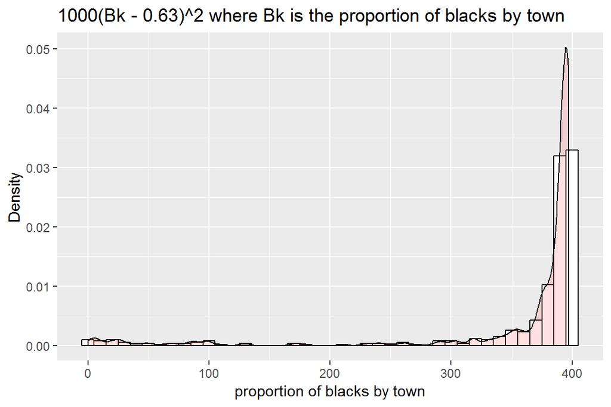

```r
ggplot(Boston, aes(x=black)) +
    geom_histogram(aes(y=..density..),
                   binwidth=10,
                   colour="black", fill="white") +
    geom_density(alpha=.2, fill="#FF6666") +
    labs(title="1000(Bk - 0.63)^2 where Bk is the proportion of blacks by town",
        x = "proportion of blacks by town",
        y = "Density")
```

```r
p = positiveCorrelation(cMat, 'black', cLimit)
# cMat['black',p]

(p = negativeCorrelation(cMat, 'black', cLimit))
```

```
## character(0)
```

```r
# cMat['black',p]
```

##### lstat

- **lower status of the population (percent)**
- right skewed distribution
- there are some poor regions?
- lstat has a high positive correlation with variables indus (0.60) and age (0.60)
- lstat has a high negative correlation with variables rm (-0.61) and medv (-0.74)

Note. Histogram is combined with density plot!

```r
summary(Boston$lstat)
```

```
##    Min. 1st Qu.  Median    Mean 3rd Qu.    Max.
##    1.73    6.95   11.36   12.65   16.95   37.97
```

```r
quantile(Boston$lstat, probs = seq(0, 1, 0.1))
```

```
##     0%    10%    20%    30%    40%    50%    60%    70%    80%    90%
##  1.730  4.680  6.290  7.765  9.530 11.360 13.330 15.620 18.060 23.035
##   100%
## 37.970
```

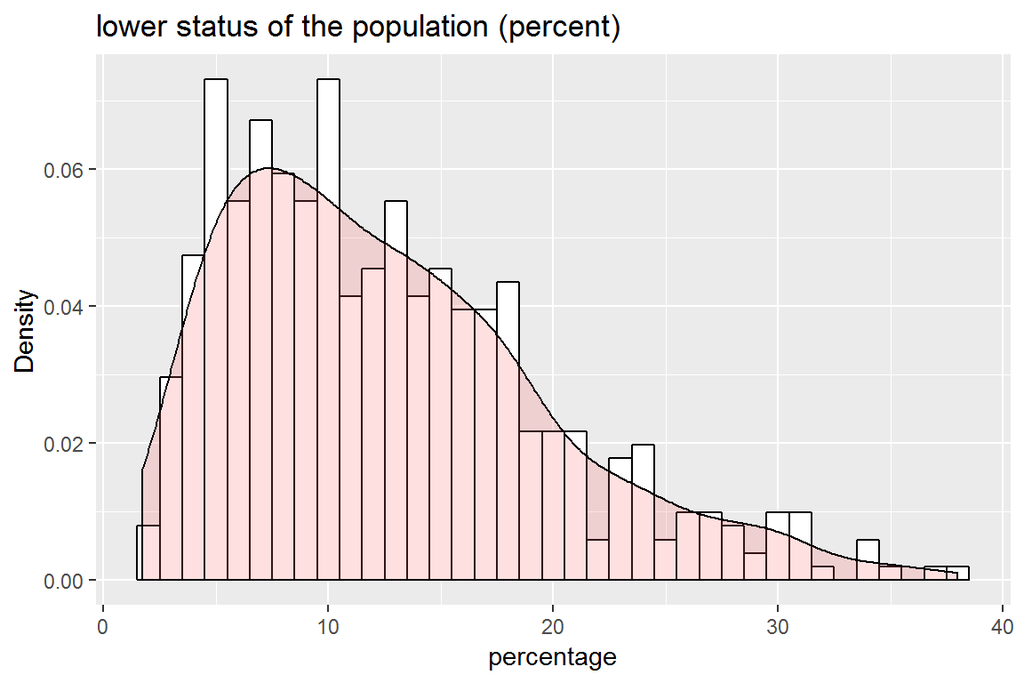

```r
ggplot(Boston, aes(x=lstat)) +
    geom_histogram(aes(y=..density..),
                   binwidth=1,
                   colour="black", fill="white") +
    geom_density(alpha=.2, fill="#FF6666") +
    labs(title="lower status of the population (percent)",
        x = "percentage",
        y = "Density")
```

```r
p = positiveCorrelation(cMat, 'lstat', cLimit)
cMat['lstat',p]
```

```
##     indus       age
## 0.6037997 0.6023385
```

```r
p = negativeCorrelation(cMat, 'lstat', cLimit)
cMat['lstat',p]
```

```
##         rm       medv
## -0.6138083 -0.7376627
```

##### medv

- **median value of owner-occupied homes in $1000s**
- there are some 20 high value areas that stand out
- otherwise distribution is near normal
- medv has a high positive correlation with variable rm (0,7)
- medv has a high negative correlation with variable lstat (-0.74)

```r
summary(Boston$medv)
```

```
##    Min. 1st Qu.  Median    Mean 3rd Qu.    Max.
##    5.00   17.02   21.20   22.53   25.00   50.00
```

```r
quantile(Boston$medv, probs = seq(0, 1, 0.1))
```

```
##    0%   10%   20%   30%   40%   50%   60%   70%   80%   90%  100%
##  5.00 12.75 15.30 18.20 19.70 21.20 22.70 24.15 28.20 34.80 50.00
```

```r
tail(sort(Boston$medv),n=20)
```

```
##  [1] 46.7 48.3 48.5 48.8 50.0 50.0 50.0 50.0 50.0 50.0 50.0 50.0 50.0 50.0
## [15] 50.0 50.0 50.0 50.0 50.0 50.0
```

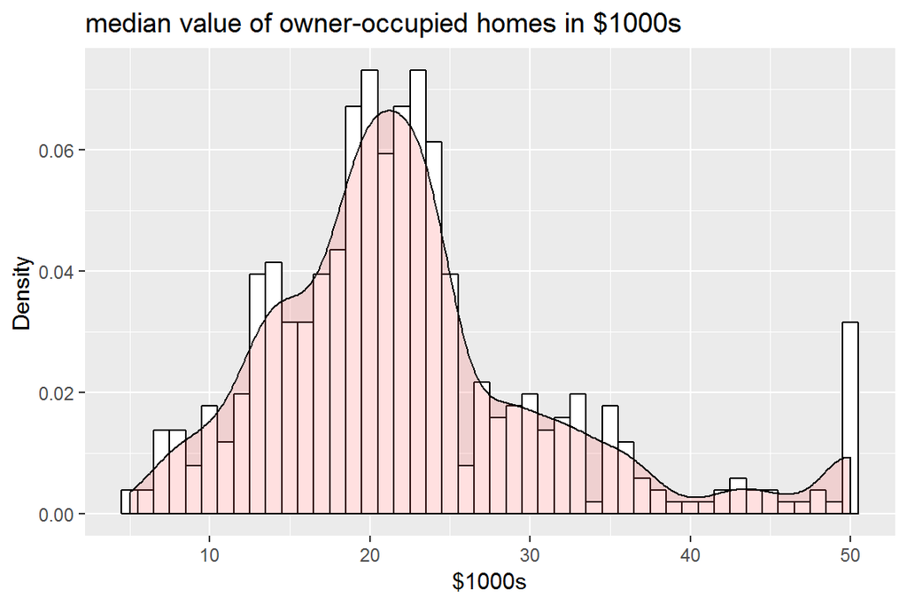

```r
ggplot(Boston, aes(x=medv)) +
    geom_histogram(aes(y=..density..),
                   binwidth=1,
                   colour="black", fill="white") +
    geom_density(alpha=.2, fill="#FF6666") +
    labs(title="median value of owner-occupied homes in $1000s",
        x = "$1000s",
        y = "Density")
```

```r
(p = positiveCorrelation(cMat, 'medv', cLimit))
```

```
## [1] "rm"
```

```r
cMat['medv',p]
```

```
## [1] 0.6953599
```

```r
(p = negativeCorrelation(cMat, 'medv', cLimit))
```

```
## [1] "lstat"
```

```r
cMat['medv',p]
```

```
## [1] -0.7376627
```

## Part III

Next I will replace the original dataset with standardized dataset.

After standardization each variable has zero mean and variance of one unit.

Standardization is common work procedure in data analysis. One main reason for this is that some tasks like dimension reduction give more accurate results when all the variables have same scale.

Note! LDA which we are going to use later on in this exercise has assumption varibles have same variance.

And if we take a closer look of couple variables, we see what happens.

In original data: - nox has range 0.385 to 0.8710 - zn has had range 0 to 100

After standardization: - nox has range -1.4644 to 2.7296 - zn has range from -0.48724 to 3.8004

```r
Boston <- as.data.frame(
  scale(Boston)
)

summary(Boston)
```

```
##       crim                 zn               indus
##  Min.   :-0.419367   Min.   :-0.48724   Min.   :-1.5563
##  1st Qu.:-0.410563   1st Qu.:-0.48724   1st Qu.:-0.8668
##  Median :-0.390280   Median :-0.48724   Median :-0.2109
##  Mean   : 0.000000   Mean   : 0.00000   Mean   : 0.0000
##  3rd Qu.: 0.007389   3rd Qu.: 0.04872   3rd Qu.: 1.0150
##  Max.   : 9.924110   Max.   : 3.80047   Max.   : 2.4202
##       chas              nox                rm               age
##  Min.   :-0.2723   Min.   :-1.4644   Min.   :-3.8764   Min.   :-2.3331
##  1st Qu.:-0.2723   1st Qu.:-0.9121   1st Qu.:-0.5681   1st Qu.:-0.8366
##  Median :-0.2723   Median :-0.1441   Median :-0.1084   Median : 0.3171
##  Mean   : 0.0000   Mean   : 0.0000   Mean   : 0.0000   Mean   : 0.0000
##  3rd Qu.:-0.2723   3rd Qu.: 0.5981   3rd Qu.: 0.4823   3rd Qu.: 0.9059
##  Max.   : 3.6648   Max.   : 2.7296   Max.   : 3.5515   Max.   : 1.1164
##       dis               rad               tax             ptratio
##  Min.   :-1.2658   Min.   :-0.9819   Min.   :-1.3127   Min.   :-2.7047
##  1st Qu.:-0.8049   1st Qu.:-0.6373   1st Qu.:-0.7668   1st Qu.:-0.4876
##  Median :-0.2790   Median :-0.5225   Median :-0.4642   Median : 0.2746
##  Mean   : 0.0000   Mean   : 0.0000   Mean   : 0.0000   Mean   : 0.0000
##  3rd Qu.: 0.6617   3rd Qu.: 1.6596   3rd Qu.: 1.5294   3rd Qu.: 0.8058
##  Max.   : 3.9566   Max.   : 1.6596   Max.   : 1.7964   Max.   : 1.6372
##      black             lstat              medv
##  Min.   :-3.9033   Min.   :-1.5296   Min.   :-1.9063
##  1st Qu.: 0.2049   1st Qu.:-0.7986   1st Qu.:-0.5989
##  Median : 0.3808   Median :-0.1811   Median :-0.1449
##  Mean   : 0.0000   Mean   : 0.0000   Mean   : 0.0000
##  3rd Qu.: 0.4332   3rd Qu.: 0.6024   3rd Qu.: 0.2683
##  Max.   : 0.4406   Max.   : 3.5453   Max.   : 2.9865
```

```r
# sd(Boston$zn)
```

Then i will create new category variable based on crime rate values.

Values are cut four bins based on the quantiles. After that will replace original continous variable with created category variable.

```r
breaks <- quantile(Boston$crim, probs = seq(0,1,0.25))

crime <- cut(Boston$crim,
             breaks = breaks,
             labels = c("low","med_low","med_high","high"),
             include.lowest = TRUE)

# replace continous variable with category variable
Boston$crim <- crime
```

Finally i will divide dataset to train and test sets.

- Split will be 80/20.
- 80 % of observations go to the trainset
- Split is done by means on random sampling

```r
# set seed for Reproductivit
set.seed(8520)

# choose randomly 80% of the rows
ind <- sample(nrow(Boston),  size = nrow(Boston) * 0.8)

# create train set
train <- Boston[ind,]

# create test set
test <- Boston[-ind,]
```

## Part IV

It’s time to fit a LDA model. Then i’ll print the summary of the model.

```r
lda.fit <- lda(crim ~ ., data = train)

lda.fit
```

```
## Call:
## lda(crim ~ ., data = train)
##
## Prior probabilities of groups:
##       low   med_low  med_high      high
## 0.2599010 0.2500000 0.2475248 0.2425743
##
## Group means:
##                   zn      indus        chas        nox          rm
## low       0.90299992 -0.9133249 -0.12234430 -0.8821438  0.43644157
## med_low  -0.06759613 -0.2458157 -0.03844192 -0.5560918 -0.12211872
## med_high -0.37404455  0.1288595  0.12138096  0.3700017  0.01537909
## high     -0.48724019  1.0149946 -0.03128211  1.0435780 -0.43784071
##                 age        dis        rad        tax     ptratio
## low      -0.9033148  0.9464190 -0.7007702 -0.7159594 -0.46556116
## med_low  -0.3433531  0.3705657 -0.5429521 -0.4744939 -0.05537785
## med_high  0.4001263 -0.3463742 -0.4581702 -0.3588952 -0.29170877
## high      0.8130824 -0.8494211  1.6596029  1.5294129  0.80577843
##                black       lstat        medv
## low       0.37797533 -0.77477029  0.49369095
## med_low   0.34493962 -0.11621450  0.00246156
## med_high  0.08023527  0.05734956  0.13212786
## high     -0.74540204  0.85737239 -0.67769227
##
## Coefficients of linear discriminants:
##                  LD1         LD2        LD3
## zn       0.166642494  0.56657293 -0.8663534
## indus   -0.009966633 -0.20029357  0.5760353
## chas    -0.001046167 -0.03704428  0.1042959
## nox      0.276664157 -0.82849016 -1.3758696
## rm       0.010597850  0.02508704 -0.1029032
## age      0.216906786 -0.38945801 -0.1432159
## dis     -0.249488659 -0.19833746  0.1553103
## rad      4.097398572  0.78736193  0.1130730
## tax      0.003440834  0.19253934  0.2159514
## ptratio  0.207313618  0.01961416 -0.2541694
## black   -0.130166633  0.02896087  0.1968306
## lstat    0.117816887 -0.18674135  0.4432566
## medv     0.044029548 -0.38264430 -0.1453663
##
## Proportion of trace:
##    LD1    LD2    LD3
## 0.9677 0.0250 0.0073
```

Then i will draw the LDA (bi)plot. I’ll skip the arrows, because i think they distract more than explain.

Data is polarised; high values define distinct groub. Which probaply explains the high percentage of LD1

Division between: low,med_low,med_high depend more on LD2 and LD3 and there aren’t clear class boundaries. Maby dataset doesn’t have enough information for LDA or maby task is beyond capablities of linear model..

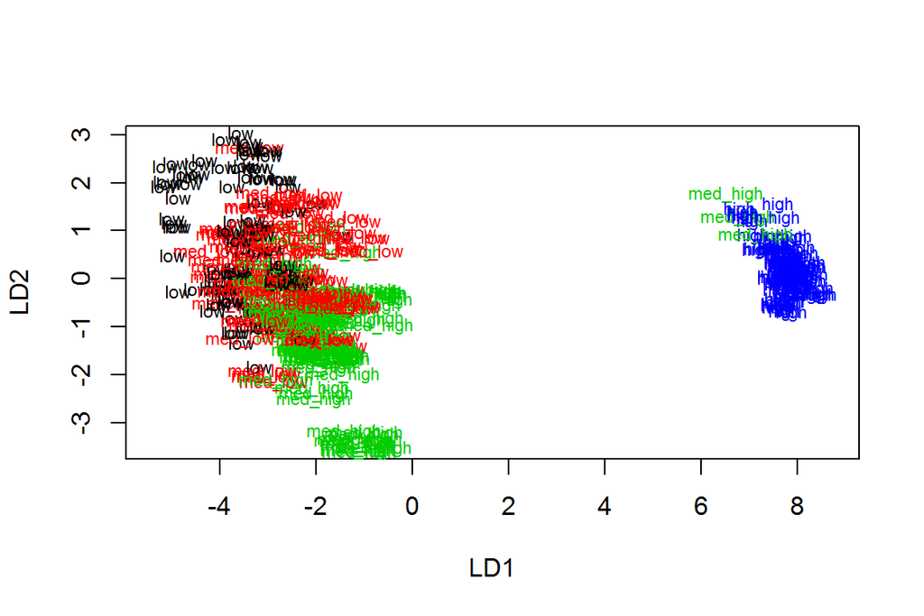

```r
# target classes as numeric
classes <- as.numeric(train$crim)

# plot the lda results
plot(lda.fit,
     col = classes,
     pch = classes,
     dimen = 2)
```

## Part V

Let’s see how my model manages with unseen data.

First I will save the crime categories from the test set and then remove the categorical crime variable from the test dataset.

Then I will predict with the LDA model on the test data.

```r
# save crime categories from the test set
categories <- test$crim
# remove variable from test set
test$crim <- NULL
# predict the classes with the LDA model on the test data
pred <- predict(lda.fit, newdata = test)

df = data.frame(obs = categories,
                pred = pred$class)
```

Finally I will analyse results with caret -packages confusionMatrix -function, which will print detailed overview of results.

- Model accuracy is way higher than **No Information rate**. No information rate is so low because there isn’t any dominant class in test set.
- In the (bi)Plot of the model we noticed that groub: **High** was clearly separated of the rest of classess. That separation can also be seen in the prediction results: sensitivity of **Class: high** is almost 100 %.
- And model has difficulities with **low**, **med_low** and **med_high** classess, which didn’t have disctinct borders in the (bi)plot either.

```r
# for starters let's print the distibution of true values
table(categories)
```

```
## categories
##      low  med_low med_high     high
##       22       25       26       29
```

```r
df = data.frame(obs = categories,
                pred = pred$class)

xtab <- table(df$pred, df$obs)

# summary of results
print(confusionMatrix(xtab))
```

```
## Confusion Matrix and Statistics
##
##
##            low med_low med_high high
##   low       14       4        1    0
##   med_low    5      14        2    0
##   med_high   3       7       20    1
##   high       0       0        3   28
##
## Overall Statistics
##
##                Accuracy : 0.7451
##                  95% CI : (0.6492, 0.8262)
##     No Information Rate : 0.2843
##     P-Value [Acc > NIR] : < 0.00000000000000022
##
##                   Kappa : 0.6581
##  Mcnemar's Test P-Value : NA
##
## Statistics by Class:
##
##                      Class: low Class: med_low Class: med_high Class: high
## Sensitivity              0.6364         0.5600          0.7692      0.9655
## Specificity              0.9375         0.9091          0.8553      0.9589
## Pos Pred Value           0.7368         0.6667          0.6452      0.9032
## Neg Pred Value           0.9036         0.8642          0.9155      0.9859
## Prevalence               0.2157         0.2451          0.2549      0.2843
## Detection Rate           0.1373         0.1373          0.1961      0.2745
## Detection Prevalence     0.1863         0.2059          0.3039      0.3039
## Balanced Accuracy        0.7869         0.7345          0.8122      0.9622
```

## Part VI

For the last part of this weeks exercises i’ll eeload the Boston dataset and standardize the dataset.

```r
# clear memory und reload data
rm(list=ls())
data("Boston")

# backup copy of original data
bak <- Boston

# standardize the dataset"
Boston <- as.data.frame(scale(Boston))
```

##### Distance of observations

Let’s calculate the distance matrix of observations

```r
# calculate the euclidean distance of observations
dist_Boston = as.matrix(dist(Boston,
                             method = "euclidean"))
```

As a sanity check lets print:

- the most similar observations
- observations that have least common

And according prints distance matrix seems to be ok.

```r
copy_of_dist <- dist_Boston

# clear diagonal axis and lower triangle, so that:
# - we have unique distances
# - don't have observations distance with itself, which is always 0
diag(copy_of_dist) <- NA
dist_Boston[lower.tri(copy_of_dist)] <- NA


# - most similar pair
bak[which(copy_of_dist==min(copy_of_dist, na.rm = TRUE), arr.ind = TRUE)[1, ], ]
```

```
##        crim zn indus chas   nox    rm  age    dis rad tax ptratio black
## 322 0.18159  0  7.38    0 0.493 6.376 54.3 4.5404   5 287    19.6 396.9
## 321 0.16760  0  7.38    0 0.493 6.426 52.3 4.5404   5 287    19.6 396.9
##     lstat medv
## 322  6.87 23.1
## 321  7.20 23.8
```

```r
# - most dissimilar pair
bak[which(copy_of_dist==max(copy_of_dist, na.rm = TRUE), arr.ind = TRUE)[1, ], ]
```

```
##         crim zn indus chas   nox    rm  age    dis rad tax ptratio  black
## 381 88.97620  0 18.10    0 0.671 6.968 91.9 1.4165  24 666    20.2 396.90
## 284  0.01501 90  1.21    1 0.401 7.923 24.8 5.8850   1 198    13.6 395.52
##     lstat medv
## 381 17.21 10.4
## 284  3.16 50.0
```

```r
rm(copy_of_dist)
```

##### K-Means clustering

First i will select the optimal number of clusters.

I’ll use so called [elbow method](https://www.r-bloggers.com/finding-optimal-number-of-clusters/) where one:

- tries different cluster counts and records each time variance explained as a function of the number of clusters
- plots findings
- looks where the gain starts to slow down

So instead of seeking smallest value we are interested in where the trend chances.

Based on the plot, two seems to be optimal number of clusters.

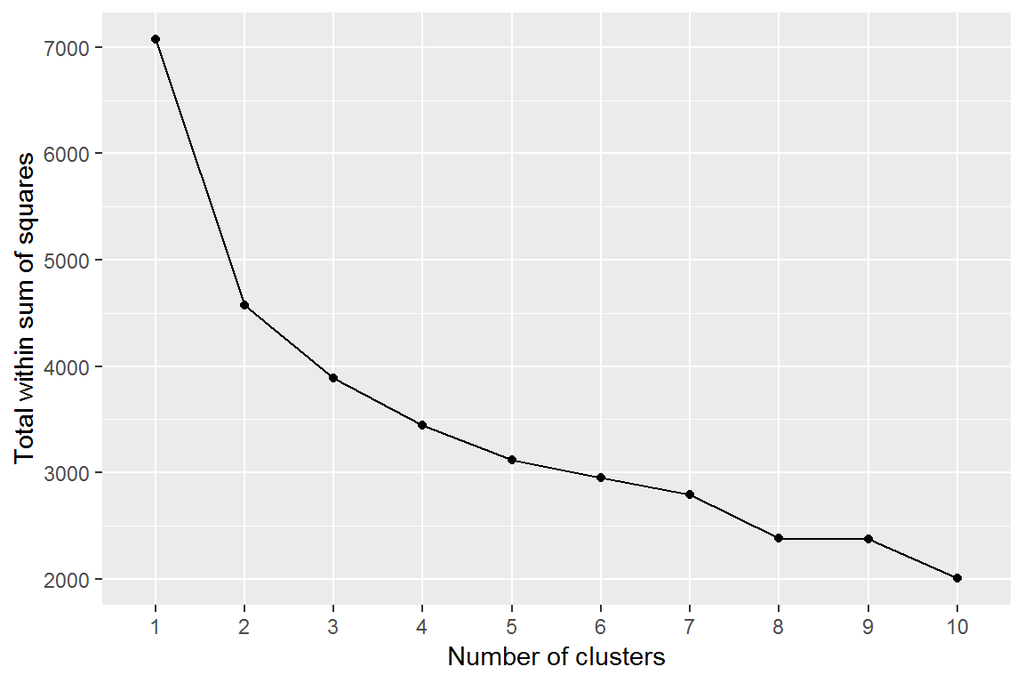

```r
set.seed(123)
k_max <- 10

# calculate the total within sum of squares
twcss <- sapply(1:k_max, function(k){kmeans(Boston, k)$tot.withinss})

df <- data.frame(val = twcss,
                 n = 1:length(twcss))

ggplot(df, aes(y = val, x = factor(n), group = 1)) +
  geom_point() +
  geom_line() +
  labs(x = "Number of clusters",
       y = "Total within sum of squares")
```

No that the number of clusters is fixed. I’ll run the clustering once again.

```r
Boston$clust <- as.factor(kmeans(Boston, 2)$cluster)
```

I’ll visualize results by means of ggpairs plot.

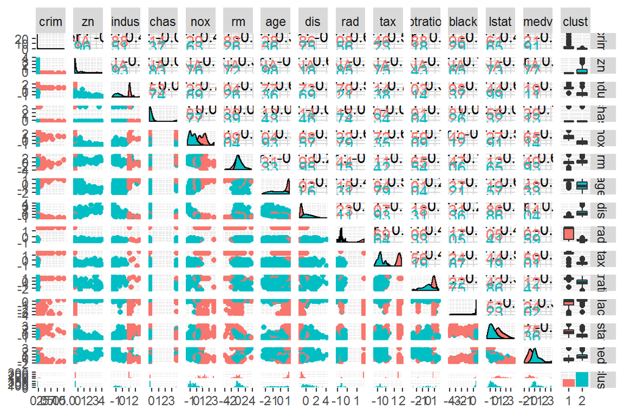

```r
ggpairs(Boston,
             mapping = aes(col = clust))
```

```r
Boston %>%
  group_by(clust) %>%
  summarise(n =n(), a = median(age))
```

```
## # A tibble: 2 x 3
##   clust     n      a
##   <fct> <int>  <dbl>
## 1 1       177  0.953
## 2 2       329 -0.429
```

Because there are “so much” variables, plot becomes disorganized.

But here are some notes:

- G2 has two times more instances than G1

Diagonal axis: - variable rm G1 and G2 have similar distributions - variable tax distributions are opposides, G2 is right skewed and G1 left skewed.

So tax values have greater influense when clustering.

And then there are variables like age, where G2 has even distribution and age is extremely left skewed. G2 has houses from various age-groups, while houses in G1 are old.

Variable dis has opposite behaviour when inspected from clustering viewpoint.

## Bonus I

I’ll reload and standardize data. Then I perform k-means clustering with k value 8. I choose that value because after that the “gain” flattens.

```r
# clear memory und reload data
rm(list=ls())
data("Boston")

# standardize the dataset"
Boston <- as.data.frame(scale(Boston))

# clustering
set.seed(8520)

Boston$clust <- as.factor(kmeans(Boston, 8)$cluster)
#kmB <- kmeans(Boston, centers = 3)
#lda.fit <- lda(kmB$cluster ~ ., data = Boston)


# table(Boston$clust)
```

Then I’ll perform the LDA analysis.

Based on the summary, there are two main discriminants that explain most of the clustering results.

```r
lda.fit <- lda(clust ~ ., data = Boston)

lda.fit
```

```
## Call:
## lda(clust ~ ., data = Boston)
##
## Prior probabilities of groups:
##          1          2          3          4          5          6
## 0.05731225 0.16403162 0.10474308 0.06521739 0.11264822 0.04150198
##          7          8
## 0.24308300 0.21146245
##
## Group means:
##         crim          zn      indus        chas         nox          rm
## 1 -0.1943934 -0.45766975  1.0664648  0.81376755  1.66401493 -0.70217263
## 2  0.4099532 -0.48724019  1.0996438  0.10715047  0.96999983 -0.20844021
## 3 -0.3694926 -0.07788488 -0.7294010  0.54480494 -0.24720899  1.62788614
## 4  1.1193656 -0.48724019  1.0149946 -0.27232907  0.99505742 -0.19450805
## 5 -0.4145302  2.46564050 -1.2005837 -0.20325713 -1.19899855  0.73436814
## 6  3.2082952 -0.48724019  1.0149946 -0.27232907  1.09984772 -1.45566793
## 7 -0.4050991 -0.06003750 -0.6727756 -0.27232907 -0.78843952 -0.07412507
## 8 -0.3706864 -0.45798756  0.1199561 -0.01476176 -0.05866413 -0.41465636
##          age        dis        rad        tax    ptratio      black
## 1  0.8510516 -0.8821602 -0.5224844 -0.1374664 -1.6805468 -0.4265968
## 2  0.7053221 -0.7569603  1.5212334  1.5454975  0.8029959  0.1622197
## 3  0.1308610 -0.2852806 -0.4943144 -0.7813708 -1.0531729  0.3441340
## 4  0.7406815 -0.8461740  1.6596029  1.5294129  0.8057784 -3.2850509
## 5 -1.4243008  1.6543851 -0.6816579 -0.5353100 -0.8473566  0.3550420
## 6  1.0064301 -1.0710604  1.6596029  1.5294129  0.8057784 -0.1691195
## 7 -0.8583613  0.7560578 -0.5701038 -0.7182404 -0.1439441  0.3723541
## 8  0.4768990 -0.3116713 -0.6126444 -0.4355997  0.5644652  0.2484973
##        lstat        medv
## 1  0.4591279 -0.35487701
## 2  0.4380837 -0.36014863
## 3 -0.9547292  1.65528163
## 4  1.1195132 -1.03254705
## 5 -0.9726664  0.82010948
## 6  2.0102765 -1.39479170
## 7 -0.5090528  0.07784778
## 8  0.3721563 -0.37853268
##
## Coefficients of linear discriminants:
##                  LD1         LD2         LD3         LD4         LD5
```

[output cut: 18 more lines]

```
## chas     0.001009047 -0.10735340
## nox     -0.264050398  0.20359257
## rm       0.254072386 -0.30862820
## age      0.056491025 -0.85007173
## dis     -0.303135175  0.82741553
## rad      0.067807913  1.24292837
## tax     -0.412470824 -0.60933483
## ptratio -0.197757600 -0.97186905
## black    0.023714659  0.06428621
## lstat    0.678594430 -0.48613347
## medv     0.710461953 -0.35848519
##
## Proportion of trace:
##    LD1    LD2    LD3    LD4    LD5    LD6    LD7
## 0.6797 0.1322 0.0783 0.0387 0.0319 0.0205 0.0187
```

Time to visualize the results with a biplot.

- There are 2 main groups
- variables rad, tax, zn and age are most influential variables
- groups are quite distict, at least 1,2,4 and 5 form clear areas

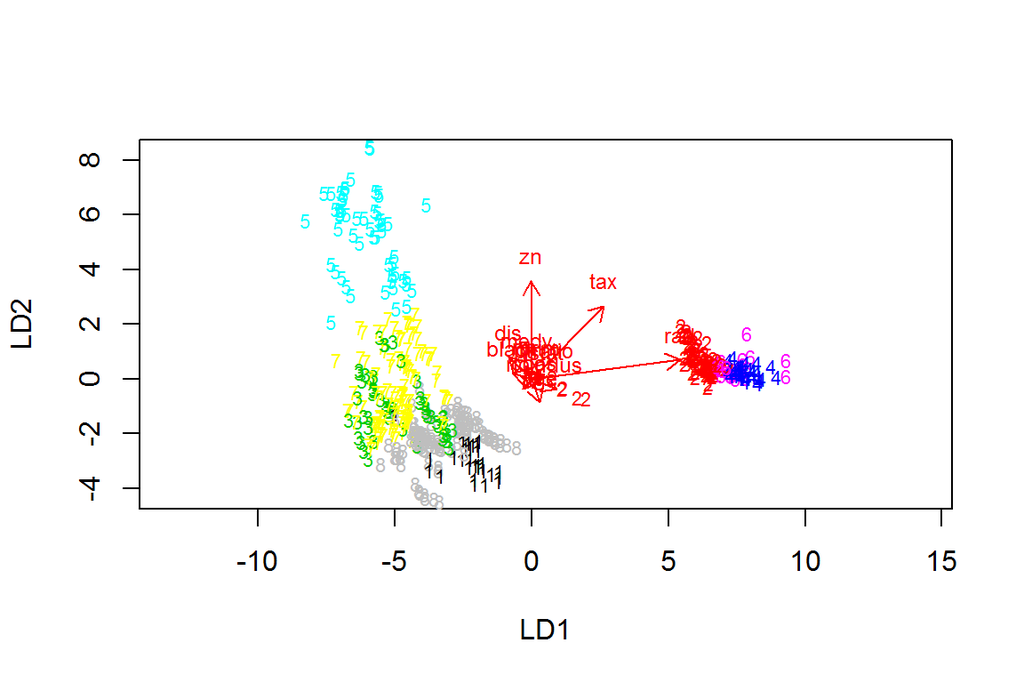

```r
lda.arrows <- function(x, myscale = 1, arrow_heads = 0.1, color = "red", tex = 0.75, choices = c(1,2)){
  heads <- coef(x)
  arrows(x0 = 0, y0 = 0,
         x1 = myscale * heads[,choices[1]],
         y1 = myscale * heads[,choices[2]], col=color, length = arrow_heads)
  text(myscale * heads[,choices], labels = row.names(heads),
       cex = tex, col=color, pos=3)
}
# target classes as numeric
classes <- as.numeric(Boston$clust)

# plot the lda results
plot(lda.fit,
     col = classes,
     pch = classes,
     dimen = 2)
lda.arrows(lda.fit, myscale = 2)
```

# Dimensionality reduction techniques

Load the packages and turn of scientific notation (of numbers):

```r
library(dplyr)
library(tidyr)

library(ggplot2)
library(corrplot)

library(GGally)
library(FactoMineR)
library(factoextra)

options(scipen=999) # disable scientific notation
```

This weeks dataset originates from the United Nations Development dataset. Datasets purpose is to compare living conditions in different countries. We don’t use original dataset, instead we have pruned where: - some of the variables have been dropped off - two new ratio variables have been added (Edu2.FM, Labo.FM)

More information about the dataset can be found [here](http://hdr.undp.org/en/content/human-development-index-hdi) and [here](http://hdr.undp.org/sites/default/files/hdr2015_technical_notes.pdf).

Read data:

```r
url = "http://s3.amazonaws.com/assets.datacamp.com/production/course_2218/datasets/human2.txt"
human <- read.table(url, sep=",", header=TRUE)
```

## Part I

I’ll start with correlations. In the graph blue circles mean positive correlation and red circles mean negative correlation, size and brightnes of color reflect the strenght of correlation. I’ll comment correlations later when i go through individual variables.

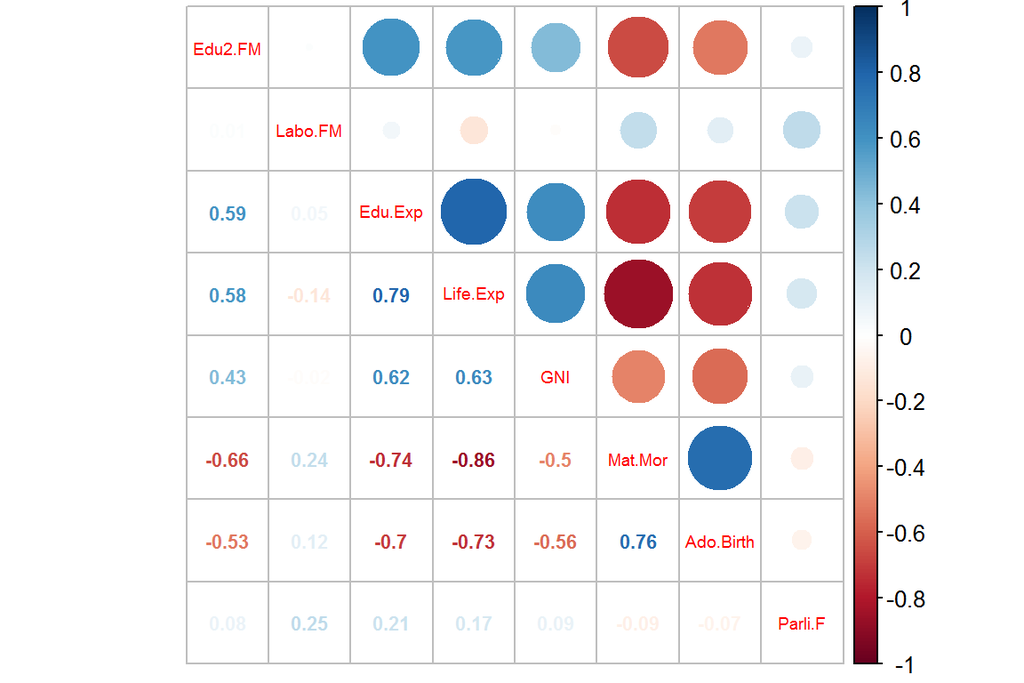

```r
# calculate the correlation matrix and round it
cor_matrix<-cor(human) %>% round(digits = 2)

# visualize the correlation matrix
corrplot.mixed(cor_matrix, number.cex = .7, tl.pos = "d", tl.cex = 0.6)
```

When number of variables is relatively small, like in this case, ggpairs -function prints handy summary graph. With custom function found from [stackoverflow](https://stackoverflow.com/questions/35085261/how-to-use-loess-method-in-ggallyggpairs-using-wrap-function) I added “regression lines” to the scatterplots.

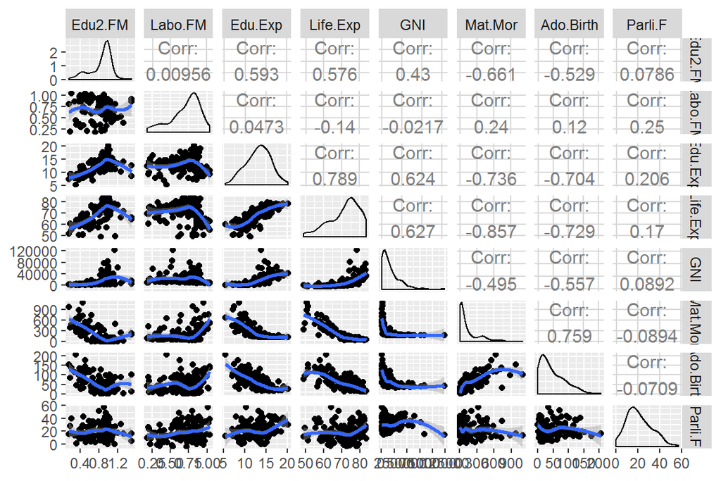